# Лабораторная работа №8

Модель конкуренции двух фирм

Автор

Федорова Анжелика Игоревна

Дата публикации

30 мая 2026 г.

# 1 Цель работы

Изучить математическую модель конкуренции двух фирм на одном рынке, реализовать численное решение системы дифференциальных уравнений для двух случаев конкуренции и проанализировать динамику оборотных средств предприятий.

# 2 Задание

В ходе работы необходимо:

1. Придумать свой пример двух конкурирующих фирм с идентичным товаром
2. Задать начальные значения и известные параметры модели
3. Построить графики изменения объёмов оборотных средств для двух случаев конкуренции
4. Найти стационарное состояние системы для первого случая
5. Проанализировать полученные результаты

# 3 Теоретическое описание

## 3.1 Модель одной фирмы

Рассматривается фирма, производящая товар долговременного пользования. Функция спроса имеет вид:

$$Q = q\left(1 - \frac{p}{p_{cr}}\right)$$

где $q$ — максимальная потребность одного потребителя, $p$ — рыночная цена, $p_{cr}$ — критическая цена отказа от покупки.

Динамика оборотных средств описывается уравнением:

$$\frac{dM}{dt} = -\frac{M\delta}{\tau} + Nq\left(1 - \frac{p}{p_{cr}}\right)p - \kappa$$

## 3.2 Модель конкуренции двух фирм

### 3.2.1 Случай 1 — рыночная конкуренция

Обе фирмы производят взаимозаменяемый товар одинакового качества. Конкуренты влияют друг на друга только через рыночный механизм. Система уравнений в безразмерном времени $\theta = t \cdot c_1$:

$$\frac{dM_1}{d\theta} = M_1 - \frac{a_1}{c_1}M_1^2 - \frac{b}{c_1}M_1 M_2$$

$$\frac{dM_2}{d\theta} = \frac{c_2}{c_1}M_2 - \frac{a_2}{c_1}M_2^2 - \frac{b}{c_1}M_1 M_2$$

### 3.2.2 Случай 2 — с социально-психологическим фактором

Дополнительное влияние через формирование общественного предпочтения одного товара другому. Коэффициент перед $M_1 M_2$ в первом уравнении увеличивается:

$$\frac{dM_1}{d\theta} = M_1 - \frac{a_1}{c_1}M_1^2 - \left(\frac{b}{c_1} + 0{,}002\right)M_1 M_2$$

$$\frac{dM_2}{d\theta} = \frac{c_2}{c_1}M_2 - \frac{a_2}{c_1}M_2^2 - \frac{b}{c_1}M_1 M_2$$

Коэффициенты модели определяются по формулам:

$$a_1 = \frac{p_{cr}}{\tau_1^2 \tilde{p}_1^2 Nq}, \quad
a_2 = \frac{p_{cr}}{\tau_2^2 \tilde{p}_2^2 Nq}, \quad
b = \frac{p_{cr}}{\tau_1^2 \tau_2^2 \tilde{p}_1^2 \tilde{p}_2^2 Nq}$$

$$c_1 = \frac{p_{cr} - \tilde{p}_1}{\tau_1 \tilde{p}_1}, \qquad
c_2 = \frac{p_{cr} - \tilde{p}_2}{\tau_2 \tilde{p}_2}$$

# 4 Ход работы

## 4.1 Описание выбранного примера

В качестве примера выбрана конкуренция двух производителей смартфонов среднего сегмента, ориентированных на одну рыночную нишу. Потребители не имеют априорных предпочтений и приобретают товар любой из фирм по единой рыночной цене.

Параметры модели

| Параметр | Обозначение | Значение |
| --- | --- | --- |
| Критическая стоимость продукта (тыс.) | $p_{cr}$ | 20 |
| Себестоимость товара фирмы 1 (тыс.) | $\tilde{p}_1$ | 9 |
| Себестоимость товара фирмы 2 (тыс.) | $\tilde{p}_2$ | 7 |
| Длительность цикла фирмы 1 | $\tau_1$ | 10 |
| Длительность цикла фирмы 2 | $\tau_2$ | 16 |
| Число потребителей (тыс. чел.) | $N$ | 10 |
| Макс. потребность одного человека | $q$ | 1 |
| Нач. оборотные средства фирмы 1 (млн) | $M_0^1$ | 2 |
| Нач. оборотные средства фирмы 2 (млн) | $M_0^2$ | 1 |

## 4.2 Реализация в Python

Скрипт `lab7.py` реализует численное решение системы ОДУ с использованием `scipy.integrate.odeint`.

```python
import numpy as np
from scipy.integrate import odeint
import matplotlib.pyplot as plt

# --- Параметры ---
p_cr = 20; tau1 = 10; tau2 = 16
p1 = 9;    p2 = 7
N = 10;    q = 1
M0 = [2.0, 1.0]

# --- Коэффициенты (формула 16) ---
a1 = p_cr / (tau1**2 * p1**2 * N * q)
a2 = p_cr / (tau2**2 * p2**2 * N * q)
b  = p_cr / (tau1**2 * tau2**2 * p1**2 * p2**2 * N * q)
c1 = (p_cr - p1) / (tau1 * p1)
c2 = (p_cr - p2) / (tau2 * p2)

theta = np.linspace(0, 30, 3000)

# --- Случай 1: рыночная конкуренция ---
def case1(M, t):
    M1, M2 = M
    dM1 = M1 - (a1/c1)*M1**2 - (b/c1)*M1*M2
    dM2 = (c2/c1)*M2 - (a2/c1)*M2**2 - (b/c1)*M1*M2
    return [dM1, dM2]

# --- Случай 2: + соц.-психол. фактор ---
def case2(M, t):
    M1, M2 = M
    dM1 = M1 - (a1/c1)*M1**2 - (b/c1 + 0.002)*M1*M2
    dM2 = (c2/c1)*M2 - (a2/c1)*M2**2 - (b/c1)*M1*M2
    return [dM1, dM2]

sol1 = odeint(case1, M0, theta)
sol2 = odeint(case2, M0, theta)

# --- Стационарные состояния (κ = 0) ---
M_plus1 = N*q*tau1*(1 - p1/p_cr)*p1
M_plus2 = N*q*tau2*(1 - p2/p_cr)*p2
print(f"М₊ фирмы 1 = {M_plus1}")
print(f"М₊ фирмы 2 = {M_plus2}")
```

### 4.2.2 Скриншот выполнения и результатов

[figure not shown]

Терминал: вывод стационарных состояний и результат запуска

## 4.3 Вычисленные коэффициенты

Подставив параметры из таблицы:

Коэффициенты системы уравнений

| Коэффициент | Значение |
| --- | --- |
| $a_1$ | 0.000247 |
| $a_2$ | 0.000159 |
| $b$ | 0.00000002 |
| $c_1$ | 0.1222 |
| $c_2$ | 0.1161 |

## 4.4 Стационарные состояния (Случай 1)

При пренебрежимо малых постоянных издержках ($\kappa = 0$) стационарное устойчивое состояние определяется по формуле (9):

$$\tilde{M}_+ = Nq\frac{\tau}{\delta}\left(1 - \frac{\tilde{p}}{p_{cr}}\right)\tilde{p}$$

Для фирмы 1:

$$\tilde{M}_+^{(1)} = 10 \cdot 1 \cdot 10 \cdot \left(1 - \frac{9}{20}\right) \cdot 9 = \mathbf{495 \text{ млн ед.}}$$

Для фирмы 2:

$$\tilde{M}_+^{(2)} = 10 \cdot 1 \cdot 16 \cdot \left(1 - \frac{7}{20}\right) \cdot 7 = \mathbf{728 \text{ млн ед.}}$$

Нижнее нестационарное состояние $\tilde{M}_- \to 0$ при $\kappa = 0$.

# 5 Результаты

## 5.2 Анализ Случая 1 — рыночная конкуренция

По графику видно, что рост оборотных средств обеих фирм идёт **независимо** друг от друга. Каждая фирма достигает своего стационарного значения и остаётся на нём:

- Фирма 1 выходит на уровень $\approx$ **495 млн ед.**
- Фирма 2 выходит на уровень $\approx$ **728 млн ед.**

Это объясняется тем, что коэффициент перед $M_1 M_2$ одинаков в обоих уравнениях (равен $b/c_1$) — взаимное рыночное давление симметрично. Обе фирмы **сосуществуют** на рынке, каждая захватывает свою долю потребителей.

## 5.3 Анализ Случая 2 — с социально-психологическим фактором

В этом случае фирма 1 подвергается **дополнительному вытеснению** за счёт социально-психологического фактора (+0.002 к коэффициенту перед $M_1 M_2$). Это моделирует ситуацию, когда потребители формируют предпочтение к товару фирмы 2 (лояльность бренду, сарафанное радио, маркетинг).

Несмотря на начальный рост, фирма 1 после достижения локального максимума ($\approx$ 220 млн ед.) начинает нести убытки и в итоге **терпит банкротство**. Фирма 2 при этом достигает своего максимального уровня и остаётся на нём, **монополизируя** рынок.

# 6 Подтверждение выполнения (скриншоты)

## 6.2 Результат выполнения скрипта

[figure not shown]

Терминал: стационарные состояния $\tilde{M}_+$ фирмы 1 (495 млн) и фирмы 2 (728 млн), сообщение об успешном сохранении графика

## 6.3 Итоговые графики

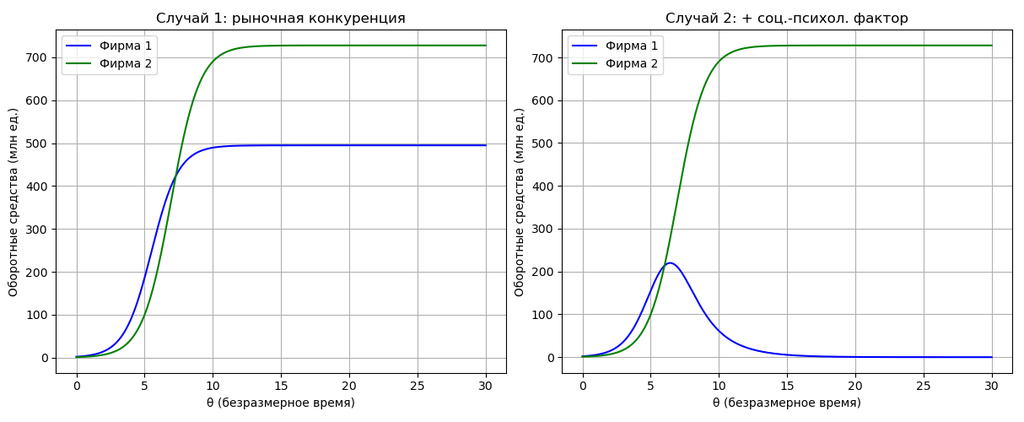

Случай 1 (слева): обе фирмы сосуществуют, каждая выходит на свой уровень. Случай 2 (справа): фирма 1 уходит в банкротство, фирма 2 монополизирует рынок

# 7 Общий анализ

# 8 Выводы

В ходе лабораторной работы:

- Реализована математическая модель конкуренции двух фирм на основе системы ОДУ; скрипт написан на Python с использованием `scipy.integrate.odeint`
- Выбран собственный пример (рынок смартфонов); заданы параметры обеих фирм и начальные условия
- Построены графики динамики оборотных средств для двух случаев конкуренции; результаты соответствуют теоретическим прогнозам
- Вычислены стационарные состояния системы для Случая 1: $\tilde{M}_+^{(1)} \approx 495$ млн ед., $\tilde{M}_+^{(2)} \approx 728$ млн ед.
- Показано, что введение социально-психологического фактора приводит к монополизации рынка одной из фирм, тогда как при чисто рыночной конкуренции обе фирмы сосуществуют

# 9 Список литературы

1. Эльсгольц Л.Э. Дифференциальные уравнения и вариационное исчисление. М.: Наука, 1969.
2. Kolmogorov A.N. Sulla teoria di Volterra della lotta per l’esistenza. Giornale dell’Istituto Italiano degli Attuari, 1936.
3. Scipy Documentation. scipy.integrate.odeint. https://docs.scipy.org/doc/scipy/reference/generated/scipy.integrate.odeint.html
4. Hunter J.D. Matplotlib: A 2D graphics environment. Computing in Science & Engineering, 2007.